# Predict Bike Sharing Demand with AutoGluon Template

## Project: Predict Bike Sharing Demand with AutoGluon

This notebook is a template with each step that you need to complete for the project.

Please fill in your code where there are explicit `?` markers in the notebook. You are welcome to add more cells and code as you see fit.

Once you have completed all the code implementations, please export your notebook as a HTML file so the reviews can view your code. Make sure you have all outputs correctly outputted.

`File-> Export Notebook As... -> Export Notebook as HTML`

There is a writeup to complete as well after all code implememtation is done. Please answer all questions and attach the necessary tables and charts. You can complete the writeup in either markdown or PDF.

Completing the code template and writeup template will cover all of the rubric points for this project.

The rubric contains "Stand Out Suggestions" for enhancing the project beyond the minimum requirements. The stand out suggestions are optional. If you decide to pursue the "stand out suggestions", you can include the code in this notebook and also discuss the results in the writeup file.

## Step 1: Create an account with Kaggle

### Create Kaggle Account and download API key

Below is example of steps to get the API username and key. Each student will have their own username and key.

1. Open account settings.

2. Scroll down to API and click Create New API Token.

3. Open up `kaggle.json` and use the username and key.


## Step 2: Download the Kaggle dataset using the kaggle python library

### Open up Sagemaker Studio and use starter template

1. Notebook should be using a `ml.t3.medium` instance (2 vCPU + 4 GiB)
2. Notebook should be using kernal: `Python 3 (MXNet 1.8 Python 3.7 CPU Optimized)`

### Install packages

```python
!pip install -U pip
!pip install -U setuptools wheel
!pip install -U "mxnet<2.0.0" bokeh==2.0.1
!pip install autogluon --no-cache-dir
# Without --no-cache-dir, smaller aws instances may have trouble installing
```

[output not shown]

[output cut: 167 more lines]

[output not shown]

### Setup Kaggle API Key

```python
# create the .kaggle directory and an empty kaggle.json file
!mkdir -p /root/.kaggle
!touch /root/.kaggle/kaggle.json
!chmod 600 /root/.kaggle/kaggle.json
```

```python
# Fill in your user name and key from creating the kaggle account and API token file
import json
kaggle_username = "wessamwalid"
kaggle_key = "44495ae81933afbbf9e7a3dda7d58033"

# Save API token the kaggle.json file
with open("/root/.kaggle/kaggle.json", "w") as f:
    f.write(json.dumps({"username": kaggle_username, "key": kaggle_key}))
```

### Download and explore dataset

### Go to the bike sharing demand competition and agree to the terms

```python
# Download the dataset, it will be in a .zip file so you'll need to unzip it as well.
!kaggle competitions download -c bike-sharing-demand
# If you already downloaded it you can use the -o command to overwrite the file
!unzip -o bike-sharing-demand.zip
```

```python
import pandas as pd
from autogluon.tabular import TabularPredictor
```

```python
# Create the train dataset in pandas by reading the csv
# Set the parsing of the datetime column so you can use some of the `dt` features in pandas later
train = pd.read_csv('/kaggle/input/bike-sharing-demand/train.csv', parse_dates=['datetime'])
train.head()
```

|  | datetime | season | holiday | workingday | weather | temp | atemp | humidity | windspeed | casual | registered | count |
| --- | --- | --- | --- | --- | --- | --- | --- | --- | --- | --- | --- | --- |
| 0 | 2011-01-01 00:00:00 | 1 | 0 | 0 | 1 | 9.84 | 14.395 | 81 | 0.0 | 3 | 13 | 16 |
| 1 | 2011-01-01 01:00:00 | 1 | 0 | 0 | 1 | 9.02 | 13.635 | 80 | 0.0 | 8 | 32 | 40 |
| 2 | 2011-01-01 02:00:00 | 1 | 0 | 0 | 1 | 9.02 | 13.635 | 80 | 0.0 | 5 | 27 | 32 |
| 3 | 2011-01-01 03:00:00 | 1 | 0 | 0 | 1 | 9.84 | 14.395 | 75 | 0.0 | 3 | 10 | 13 |
| 4 | 2011-01-01 04:00:00 | 1 | 0 | 0 | 1 | 9.84 | 14.395 | 75 | 0.0 | 0 | 1 | 1 |

```python
# Simple output of the train dataset to view some of the min/max/varition of the dataset features.
train.describe()
```

|  | datetime | season | holiday | workingday | weather | temp | atemp | humidity | windspeed | casual | registered | count |
| --- | --- | --- | --- | --- | --- | --- | --- | --- | --- | --- | --- | --- |
| count | 10886 | 10886.000000 | 10886.000000 | 10886.000000 | 10886.000000 | 10886.00000 | 10886.000000 | 10886.000000 | 10886.000000 | 10886.000000 | 10886.000000 | 10886.000000 |
| mean | 2011-12-27 05:56:22.399411968 | 2.506614 | 0.028569 | 0.680875 | 1.418427 | 20.23086 | 23.655084 | 61.886460 | 12.799395 | 36.021955 | 155.552177 | 191.574132 |
| min | 2011-01-01 00:00:00 | 1.000000 | 0.000000 | 0.000000 | 1.000000 | 0.82000 | 0.760000 | 0.000000 | 0.000000 | 0.000000 | 0.000000 | 1.000000 |
| 25% | 2011-07-02 07:15:00 | 2.000000 | 0.000000 | 0.000000 | 1.000000 | 13.94000 | 16.665000 | 47.000000 | 7.001500 | 4.000000 | 36.000000 | 42.000000 |
| 50% | 2012-01-01 20:30:00 | 3.000000 | 0.000000 | 1.000000 | 1.000000 | 20.50000 | 24.240000 | 62.000000 | 12.998000 | 17.000000 | 118.000000 | 145.000000 |
| 75% | 2012-07-01 12:45:00 | 4.000000 | 0.000000 | 1.000000 | 2.000000 | 26.24000 | 31.060000 | 77.000000 | 16.997900 | 49.000000 | 222.000000 | 284.000000 |
| max | 2012-12-19 23:00:00 | 4.000000 | 1.000000 | 1.000000 | 4.000000 | 41.00000 | 45.455000 | 100.000000 | 56.996900 | 367.000000 | 886.000000 | 977.000000 |
| std | NaN | 1.116174 | 0.166599 | 0.466159 | 0.633839 | 7.79159 | 8.474601 | 19.245033 | 8.164537 | 49.960477 | 151.039033 | 181.144454 |

```python
train.info()
```

```
<class 'pandas.core.frame.DataFrame'>
RangeIndex: 10886 entries, 0 to 10885
Data columns (total 12 columns):
 #   Column      Non-Null Count  Dtype
---  ------      --------------  -----
 0   datetime    10886 non-null  datetime64[ns]
 1   season      10886 non-null  int64
 2   holiday     10886 non-null  int64
 3   workingday  10886 non-null  int64
 4   weather     10886 non-null  int64
 5   temp        10886 non-null  float64
 6   atemp       10886 non-null  float64
 7   humidity    10886 non-null  int64
 8   windspeed   10886 non-null  float64
 9   casual      10886 non-null  int64
 10  registered  10886 non-null  int64
 11  count       10886 non-null  int64
dtypes: datetime64[ns](1), float64(3), int64(8)
memory usage: 1020.7 KB
```

```python
# Create the test pandas dataframe in pandas by reading the csv, remember to parse the datetime!
test = pd.read_csv('/kaggle/input/bike-sharing-demand/test.csv', parse_dates=['datetime'])
test.head()
```

|  | datetime | season | holiday | workingday | weather | temp | atemp | humidity | windspeed |
| --- | --- | --- | --- | --- | --- | --- | --- | --- | --- |
| 0 | 2011-01-20 00:00:00 | 1 | 0 | 1 | 1 | 10.66 | 11.365 | 56 | 26.0027 |
| 1 | 2011-01-20 01:00:00 | 1 | 0 | 1 | 1 | 10.66 | 13.635 | 56 | 0.0000 |
| 2 | 2011-01-20 02:00:00 | 1 | 0 | 1 | 1 | 10.66 | 13.635 | 56 | 0.0000 |
| 3 | 2011-01-20 03:00:00 | 1 | 0 | 1 | 1 | 10.66 | 12.880 | 56 | 11.0014 |
| 4 | 2011-01-20 04:00:00 | 1 | 0 | 1 | 1 | 10.66 | 12.880 | 56 | 11.0014 |

```python
# Same thing as train and test dataset
submission = pd.read_csv('/kaggle/input/bike-sharing-demand/sampleSubmission.csv', parse_dates=['datetime'])
submission.head()
```

|  | datetime | count |
| --- | --- | --- |
| 0 | 2011-01-20 00:00:00 | 0 |
| 1 | 2011-01-20 01:00:00 | 0 |
| 2 | 2011-01-20 02:00:00 | 0 |
| 3 | 2011-01-20 03:00:00 | 0 |
| 4 | 2011-01-20 04:00:00 | 0 |

## Step 3: Train a model using AutoGluon’s Tabular Prediction

Requirements:

- We are prediting `count`, so it is the label we are setting.
- Ignore `casual` and `registered` columns as they are also not present in the test dataset.
- Use the `root_mean_squared_error` as the metric to use for evaluation.
- Set a time limit of 10 minutes (600 seconds).
- Use the preset `best_quality` to focus on creating the best model.

```python
predictor = TabularPredictor(
    label="count",
    eval_metric = 'root_mean_squared_error',
    verbosity=0,
    learner_kwargs={"ignored_columns": ["casual", "registered"]}).fit(
    train_data=train,
    time_limit=600,
    presets="best_quality"
)
```

### Review AutoGluon's training run with ranking of models that did the best.

```python
predictor.fit_summary()
```

```
*** Summary of fit() ***
Estimated performance of each model:
                     model   score_val              eval_metric  pred_time_val    fit_time  pred_time_val_marginal  fit_time_marginal  stack_level  can_infer  fit_order
0      WeightedEnsemble_L3  -54.875620  root_mean_squared_error      55.588703  383.212827                0.000918           0.046129            3       True         12
1          LightGBM_BAG_L2  -54.936910  root_mean_squared_error      43.301507  308.257999                0.713637          22.252174            2       True         11
2        LightGBMXT_BAG_L2  -60.424759  root_mean_squared_error      54.874148  360.914523               12.286278          74.908699            2       True         10
3    KNeighborsDist_BAG_L1  -84.169493  root_mean_squared_error       0.049255    0.045832                0.049255           0.045832            1       True          2
4      WeightedEnsemble_L2  -84.169493  root_mean_squared_error       0.054911    0.218415                0.005656           0.172584            2       True          9
5    KNeighborsUnif_BAG_L1 -101.632965  root_mean_squared_error       0.074080    0.352632                0.074080           0.352632            1       True          1
6   RandomForestMSE_BAG_L1 -116.548359  root_mean_squared_error       0.731868    9.199376                0.731868           9.199376            1       True          5
7     ExtraTreesMSE_BAG_L1 -124.600676  root_mean_squared_error       0.730856    4.213104                0.730856           4.213104            1       True          7
8          CatBoost_BAG_L1 -130.573922  root_mean_squared_error       0.129917  111.106231                0.129917         111.106231            1       True          6
9          LightGBM_BAG_L1 -131.054162  root_mean_squared_error       4.984868   29.305730                4.984868          29.305730            1       True          4
10       LightGBMXT_BAG_L1 -131.460909  root_mean_squared_error      35.266291   98.132873               35.266291          98.132873            1       True          3
11  NeuralNetFastAI_BAG_L1 -142.445781  root_mean_squared_error       0.620736   33.650046                0.620736          33.650046            1       True          8
Number of models trained: 12
Types of models trained:
{'StackerEnsembleModel_XT', 'WeightedEnsembleModel', 'StackerEnsembleModel_RF', 'StackerEnsembleModel_NNFastAiTabular', 'StackerEnsembleModel_CatBoost', 'StackerEnsembleModel_KNN', 'StackerEnsembleModel_LGB'}
Bagging used: True  (with 8 folds)
Multi-layer stack-ensembling used: True  (with 3 levels)
Feature Metadata (Processed):
(raw dtype, special dtypes):
('float', [])                : 3 | ['temp', 'atemp', 'windspeed']
('int', [])                  : 3 | ['season', 'weather', 'humidity']
('int', ['bool'])            : 2 | ['holiday', 'workingday']
('int', ['datetime_as_int']) : 5 | ['datetime', 'datetime.year', 'datetime.month', 'datetime.day', 'datetime.dayofweek']
*** End of fit() summary ***
```

[output not shown]

[output cut: 101 more lines]

```
 11       0.620736   33.650046                0.620736          33.650046

     stack_level  can_infer  fit_order
 0             3       True         12
 1             2       True         11
 2             2       True         10
 3             1       True          2
 4             2       True          9
 5             1       True          1
 6             1       True          5
 7             1       True          7
 8             1       True          6
 9             1       True          4
 10            1       True          3
 11            1       True          8  }
```

### Create predictions from test dataset

```python
predictions = predictor.predict(test)
predictions.head()
```

```
INFO:sklearnex: sklearn.neighbors.KNeighborsRegressor.predict: running accelerated version on CPU
INFO:sklearnex: sklearn.utils.validation._assert_all_finite: running accelerated version on CPU
INFO:sklearnex: sklearn.neighbors.KNeighborsRegressor.predict: running accelerated version on CPU
INFO:sklearnex: sklearn.utils.validation._assert_all_finite: running accelerated version on CPU
```

```
0    34.827339
1    44.475742
2    48.391380
3    51.323425
4    52.083378
Name: count, dtype: float32
```

#### NOTE: Kaggle will reject the submission if we don't set everything to be > 0.

```python
# Describe the `predictions` series to see if there are any negative values
predictions.describe()
```

```
count    6493.000000
mean       99.375847
std        89.990486
min        -6.201339
25%        16.143431
50%        61.973495
75%       171.965668
max       368.622192
Name: count, dtype: float64
```

```python
# How many negative values do we have?
predictions.lt(0).sum().sum()
```

```
5
```

```python
# Set them to zero
predictions = predictions.clip(lower=0)
```

### Set predictions to submission dataframe, save, and submit

```python
submission["count"] = predictions
submission['count'] = submission['count'].apply(lambda x: round(x))
submission.to_csv("submission.csv", index=False)
```

```python
!kaggle competitions submit -c bike-sharing-demand -f submission.csv -m "first raw submission"
```

#### View submission via the command line or in the web browser under the competition's page - `My Submissions`

```python
!kaggle competitions submissions -c bike-sharing-demand | tail -n +1 | head -n 6
```

[output not shown]

#### Initial score of `1.84`

## Step 4: Exploratory Data Analysis and Creating an additional feature

- Any additional feature will do, but a great suggestion would be to separate out the datetime into hour, day, or month parts.

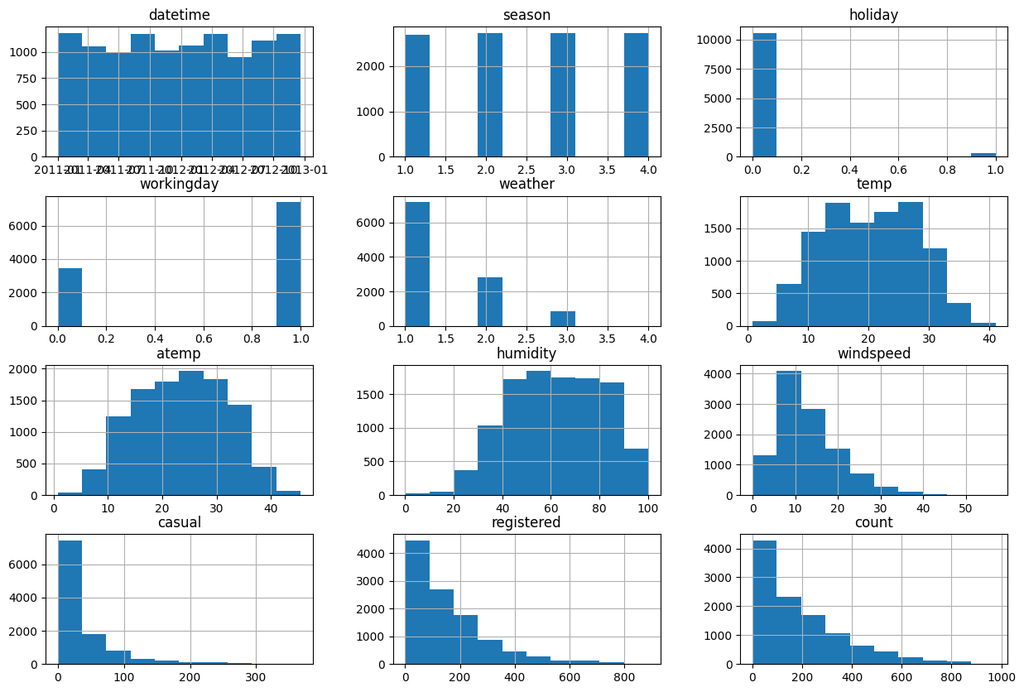

```python
# Create a histogram of all features to show the distribution of each one relative to the data. This is part of the exploritory data analysis
train.hist(figsize = (15,10));
```

```python
train['hour'] = train['datetime'].dt.hour
train['day'] = train['datetime'].dt.day
train['month'] = train['datetime'].dt.month
test['hour'] = test['datetime'].dt.hour
test['day'] = test['datetime'].dt.day
test['month'] = test['datetime'].dt.month
```

```python
# create a new feature
def time_of_day(x):
    if (x > 4) and (x <= 8):
        return 0 # Early Morning
    elif (x > 8) and (x <= 12 ):
        return 1 # Morning
    elif (x > 12) and (x <= 16):
        return 2 # Noon
    elif (x > 16) and (x <= 20) :
        return 3 # Evening
    elif (x > 20) and (x <= 24):
        return 4 # Night
    elif (x <= 4):
        return 5 # Late Night


train['time_of_day'] = train['hour'].apply(time_of_day)
test['time_of_day'] = test['hour'].apply(time_of_day)
```

```python
def temp_category(x):
    if x <= 10:
        return 0
    elif (x > 10) and (x <= 25 ):
        return 1
    elif (x > 25):
        return 2


train['temp_category'] = train['temp'].apply(temp_category)
test['temp_category'] = test['temp'].apply(temp_category)
```

```python
def wind_category(x):
    if x <= 15:
        return 0
    elif (x > 10):
        return 1


train['wind_category'] = train['windspeed'].apply(wind_category)
test['wind_category'] = test['windspeed'].apply(wind_category)
```

```python
def humid_category(x):
    if x <= 30:
        return 0 # low humidity
    elif (x > 30) and (x <= 50 ):
        return 1 # normal humidity
    elif (x > 50):
        return 2 # high humidity

train['humid_category'] = train['humidity'].apply(humid_category)
test['humid_category'] = test['humidity'].apply(humid_category)
```

```python
def atemp_category(x):
    if x <= 10:
        return 0 # low temp
    elif (x > 10) and (x <= 25 ):
        return 1 # mild temp
    elif (x > 25):
        return 2 # hot temp


train['atemp_category'] = train['atemp'].apply(atemp_category)
test['atemp_category'] = test['atemp'].apply(atemp_category)
```

```python
train.drop(['datetime', 'temp', 'windspeed', 'humidity', 'atemp'], axis=1, inplace=True)
test.drop(['datetime', 'temp', 'windspeed', 'humidity', 'atemp'], axis=1, inplace=True)
```

## Make category types for these so models know they are not just numbers

- AutoGluon originally sees these as ints, but in reality they are int representations of a category.
- Setting the dtype to category will classify these as categories in AutoGluon.

```python
train.info()
```

[output not shown]

```python
train["season"] = train["season"].astype("category")
train["weather"] = train["weather"].astype("category")
test["season"] = test["season"].astype("category")
test["weather"] = test["weather"].astype("category")
```

```python
# View are new feature
train.head()
```

|  | season | holiday | workingday | weather | casual | registered | count | hour | day | month | time_of_day | temp_category | wind_category | humid_category | atemp_category |
| --- | --- | --- | --- | --- | --- | --- | --- | --- | --- | --- | --- | --- | --- | --- | --- |
| 0 | 1 | 0 | 0 | 1 | 3 | 13 | 16 | 0 | 1 | 1 | 5 | 0 | 0 | 2 | 1 |
| 1 | 1 | 0 | 0 | 1 | 8 | 32 | 40 | 1 | 1 | 1 | 5 | 0 | 0 | 2 | 1 |
| 2 | 1 | 0 | 0 | 1 | 5 | 27 | 32 | 2 | 1 | 1 | 5 | 0 | 0 | 2 | 1 |
| 3 | 1 | 0 | 0 | 1 | 3 | 10 | 13 | 3 | 1 | 1 | 5 | 0 | 0 | 2 | 1 |
| 4 | 1 | 0 | 0 | 1 | 0 | 1 | 1 | 4 | 1 | 1 | 5 | 0 | 0 | 2 | 1 |

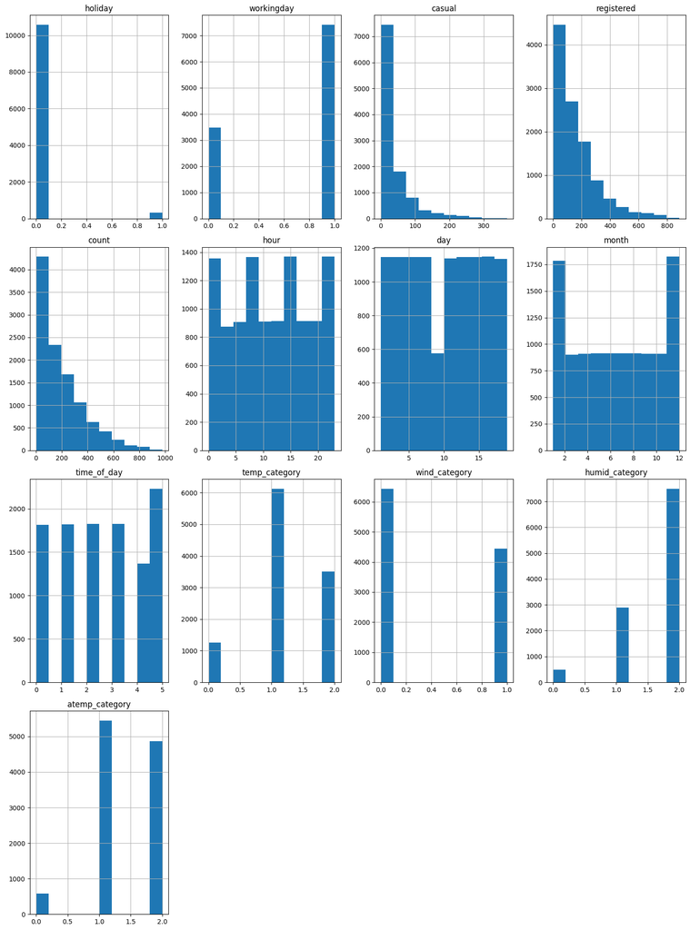

```python
# View histogram of all features again now with the hour feature
import matplotlib.pyplot as plt

train.hist(figsize=(15,20))  # Note: 'casual' and 'registered' are ignored during training as they are absent in test data

plt.tight_layout()
plt.show()
```

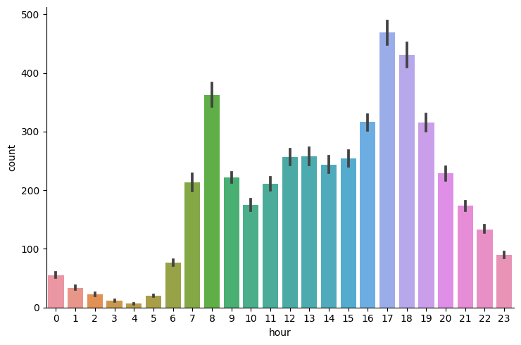

```python
import seaborn as sns

sns.catplot(x="hour",y="count",data=train,kind='bar',height=5,aspect=1.5)
plt.tight_layout()
plt.show()
```

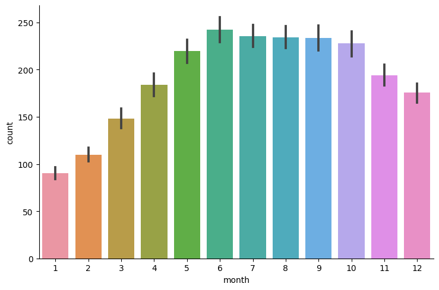

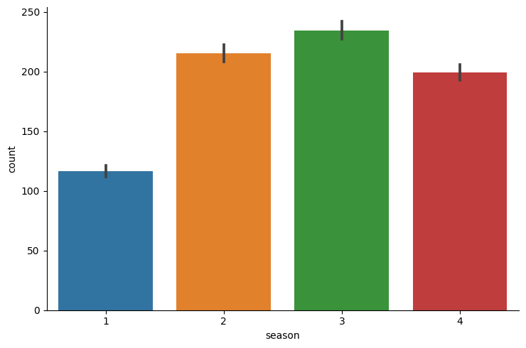

```python
sns.catplot(x="month",y="count",data=train,kind='bar',height=5,aspect=1.5)
sns.catplot(x="season",y="count",data=train,kind='bar',height=5,aspect=1.5)
plt.tight_layout()
plt.show()
```

> Since seasons show variation in the number of bike rentals count, it is obvious to notice the same from the month feature, but at a slightly more granular level.

```python
train.info()
```

[output not shown]

```python
train.drop(["atemp_category"], axis=1, inplace=True)
```

## Step 5: Rerun the model with the same settings as before, just with more features

```python
eval_metric = 'root_mean_squared_error'
label = 'count'
ignored_columns = ["casual", "registered"]   # Ignored columns while training
train_data = train                           # 'casual' and 'registered' columns are already dropped/ignored
time_limit = 600                             # 10 minutes -> 60*10 = 600 seconds
presets = "best_quality"
```

```python
predictor_new_features = TabularPredictor(label=label,
                                          problem_type= 'regression',
                                          eval_metric=eval_metric,
                                          learner_kwargs={'ignored_columns': ignored_columns}).fit(
                                                                                           train_data = train_data,
                                                                                           time_limit=time_limit,
                                                                                           presets=presets)
```

[output not shown]

[output cut: 96 more lines]

```
	-56.608	 = Validation score   (-root_mean_squared_error)
	5.08s	 = Training   runtime
	0.75s	 = Validation runtime
Fitting model: NeuralNetFastAI_BAG_L2 ... Training model for up to 18.94s of the 18.91s of remaining time.
	Fitting 8 child models (S1F1 - S1F8) | Fitting with ParallelLocalFoldFittingStrategy (4 workers, per: cpus=1, gpus=0, memory=0.02%)
	-56.5935	 = Validation score   (-root_mean_squared_error)
	41.9s	 = Training   runtime
	1.09s	 = Validation runtime
Fitting model: WeightedEnsemble_L3 ... Training model for up to 360.0s of the -28.22s of remaining time.
	Ensemble Weights: {'CatBoost_BAG_L2': 0.318, 'RandomForestMSE_BAG_L2': 0.273, 'LightGBM_BAG_L2': 0.182, 'NeuralNetFastAI_BAG_L2': 0.182, 'ExtraTreesMSE_BAG_L2': 0.045}
	-54.9613	 = Validation score   (-root_mean_squared_error)
	0.12s	 = Training   runtime
	0.0s	 = Validation runtime
AutoGluon training complete, total runtime = 465.42s ... Best model: "WeightedEnsemble_L3"
TabularPredictor saved. To load, use: predictor = TabularPredictor.load("AutogluonModels/ag-20240426_162224")
```

```python
predictor_new_features.fit_summary()
```

```
*** Summary of fit() ***
Estimated performance of each model:
                     model   score_val              eval_metric  pred_time_val    fit_time  pred_time_val_marginal  fit_time_marginal  stack_level  can_infer  fit_order
0      WeightedEnsemble_L3  -54.961322  root_mean_squared_error     178.772938  383.610482                0.002637           0.122855            3       True         12
1          CatBoost_BAG_L2  -55.524062  root_mean_squared_error     175.670252  305.486547                0.130443          40.481777            2       True          9
2          LightGBM_BAG_L2  -55.690177  root_mean_squared_error     176.028552  283.084300                0.488743          18.079529            2       True          7
3   RandomForestMSE_BAG_L2  -56.266273  root_mean_squared_error     176.314304  277.939871                0.774495          12.935100            2       True          8
4   NeuralNetFastAI_BAG_L2  -56.593480  root_mean_squared_error     176.629449  306.909732                1.089640          41.904961            2       True         11
5     ExtraTreesMSE_BAG_L2  -56.608033  root_mean_squared_error     176.286980  270.086259                0.747171           5.081489            2       True         10
6        LightGBMXT_BAG_L2  -57.707388  root_mean_squared_error     177.421777  288.349274                1.881968          23.344503            2       True          6
7      WeightedEnsemble_L2  -58.915848  root_mean_squared_error     175.398253  264.941598                0.000819           0.022193            2       True          5
8          LightGBM_BAG_L1  -59.105911  root_mean_squared_error      42.409846   89.640406               42.409846          89.640406            1       True          4
9        LightGBMXT_BAG_L1  -67.240320  root_mean_squared_error     132.987589  175.278999              132.987589         175.278999            1       True          3
10   KNeighborsUnif_BAG_L1 -108.903141  root_mean_squared_error       0.063221    0.045691                0.063221           0.045691            1       True          1
11   KNeighborsDist_BAG_L1 -137.752570  root_mean_squared_error       0.079153    0.039674                0.079153           0.039674            1       True          2
Number of models trained: 12
Types of models trained:
{'StackerEnsembleModel_XT', 'WeightedEnsembleModel', 'StackerEnsembleModel_RF', 'StackerEnsembleModel_NNFastAiTabular', 'StackerEnsembleModel_CatBoost', 'StackerEnsembleModel_KNN', 'StackerEnsembleModel_LGB'}
Bagging used: True  (with 8 folds)
Multi-layer stack-ensembling used: True  (with 3 levels)
Feature Metadata (Processed):
(raw dtype, special dtypes):
('category', [])  : 2 | ['season', 'weather']
('int', [])       : 6 | ['hour', 'day', 'month', 'time_of_day', 'temp_category', ...]
('int', ['bool']) : 3 | ['holiday', 'workingday', 'wind_category']
*** End of fit() summary ***
```

[output not shown]

[output cut: 101 more lines]

```
 11       0.079153    0.039674                0.079153           0.039674

     stack_level  can_infer  fit_order
 0             3       True         12
 1             2       True          9
 2             2       True          7
 3             2       True          8
 4             2       True         11
 5             2       True         10
 6             2       True          6
 7             2       True          5
 8             1       True          4
 9             1       True          3
 10            1       True          1
 11            1       True          2  }
```

```python
predictions_new_features = predictor_new_features.predict(test)
predictions_new_features.head()
```

```
INFO:sklearnex: sklearn.neighbors.KNeighborsRegressor.predict: running accelerated version on CPU
INFO:sklearnex: sklearn.utils.validation._assert_all_finite: running accelerated version on CPU
INFO:sklearnex: sklearn.neighbors.KNeighborsRegressor.predict: running accelerated version on CPU
INFO:sklearnex: sklearn.utils.validation._assert_all_finite: running accelerated version on CPU
```

```
0    10.000658
1     7.023954
2     5.254492
3     4.123707
4     4.192562
Name: count, dtype: float32
```

```python
predictions_new_features.describe()
```

```
count    6493.000000
mean      196.219757
std       174.485229
min         2.153929
25%        52.014080
50%       158.041565
75%       279.454651
max       871.628296
Name: count, dtype: float64
```

```python
# Rechecking the predictions in predictions_new_features
negative_pred_count = predictions_new_features.apply(lambda x: 1 if x<0 else 0)

pred_pos_count = (negative_pred_count==0).sum()
pred_neg_count = (negative_pred_count==1).sum()

print("Total predictions                :", len(predictions_new_features.index))
print("Total positive prediction values :", pred_pos_count)
print("Total negative prediction values :", pred_neg_count)
```

```
Total predictions                : 6493
Total positive prediction values : 6493
Total negative prediction values : 0
```

```python
# Remember to set all negative values to zero
predictions_new_features[predictions_new_features<0] = 0    # (In case, if negative values exist in the predictions_new_features, set them to 0)

# Rechecking, if no predictions are less than 0
negative_pred_count = predictions_new_features.apply(lambda x: 1 if x<0 else 0)
pred_neg_count = (negative_pred_count==1).sum()
print(f"No. of negative predictions: {pred_neg_count}")
print("All negative values in the predictions (if any) are set to zero successfully.")
```

```
No. of negative predictions: 0
All negative values in the predictions (if any) are set to zero successfully.
```

```python
submission_new_features = pd.read_csv('sampleSubmission.csv', parse_dates = ['datetime'])
submission_new_features.head()
```

|  | datetime | count |
| --- | --- | --- |
| 0 | 2011-01-20 00:00:00 | 0 |
| 1 | 2011-01-20 01:00:00 | 0 |
| 2 | 2011-01-20 02:00:00 | 0 |
| 3 | 2011-01-20 03:00:00 | 0 |
| 4 | 2011-01-20 04:00:00 | 0 |

```python
# Same submitting predictions
submission_new_features["count"] = predictions_new_features
submission_new_features.to_csv("submission_new_features.csv", index=False)
```

```python
!kaggle competitions submit -c bike-sharing-demand -f submission_new_features.csv -m "new features"
```

```python
!kaggle competitions submissions -c bike-sharing-demand | tail -n +1 | head -n 6
```

[output not shown]

#### New Score of `0.61`

## Step 6: Hyper parameter optimization

- There are many options for hyper parameter optimization.
- Options are to change the AutoGluon higher level parameters or the individual model hyperparameters.
- The hyperparameters of the models themselves that are in AutoGluon. Those need the `hyperparameter` and `hyperparameter_tune_kwargs` arguments.

```python
!pip install -q ipywidgets==7.4.2
!jupyter nbextension enable --py --sys-prefix widgetsnbextension
```

[output not shown]

```python
import autogluon.common as ag
## From autogluon documentation

nn_options = {'num_epochs': 5,
              'learning_rate': ag.space.Real(1e-4, 1e-2, default=5e-4, log=True),
                    # learning rate used in training (real-valued hyperparameter searched on log-scale)
              'activation': ag.space.Categorical('relu', 'softrelu', 'tanh'),
                    # activation function used in NN (categorical hyperparameter, default = first entry)
              'dropout_prob': ag.space.Real(0.0, 0.5, default=0.1)}

gbm_options = [{'extra_trees': True,
                'num_boost_round': ag.space.Int(lower=100, upper=500, default=100),
                'num_leaves': ag.space.Int(lower=25, upper=64, default=36),
                'ag_args': {'name_suffix': 'XT'}}, {}, 'GBMLarge']

hyperparameters = {  # hyperparameters of each model type
    'GBM': gbm_options,
    'CAT': {'iterations': 10000},
    'RF': {'n_estimators': 300},
    'XT': {'n_estimators': 300}
                  }

num_trials = 20            # Number of hyperparameter optimization trials you want to perform
search_strategy = 'auto'  # tune hyperparameters using Bayesian optimization routine with a local scheduler
scheduler = 'local'       # Local FIFO scheduler

hyperparameter_tune_kwargs = {
    'num_trials': num_trials,
    'scheduler' : scheduler,
    'searcher': search_strategy,
}

predictor_new_hpo = TabularPredictor(label='count', problem_type='regression', eval_metric='root_mean_squared_error',
                                    learner_kwargs={'ignored_columns': ignored_columns}).fit(
                                                                         train_data=train,
                                                                         time_limit=time_limit,
                                                                         presets=presets,
                                                                         hyperparameters=hyperparameters,
                                                                         hyperparameter_tune_kwargs=hyperparameter_tune_kwargs,
                                                                         refit_full='best')
```

[output not shown]

[output cut: 18 more lines]

```
	Train Data (Processed) Memory Usage: 0.43 MB (0.0% of available memory)
Data preprocessing and feature engineering runtime = 0.15s ...
AutoGluon will gauge predictive performance using evaluation metric: 'root_mean_squared_error'
	This metric's sign has been flipped to adhere to being higher_is_better. The metric score can be multiplied by -1 to get the metric value.
	To change this, specify the eval_metric parameter of Predictor()
User-specified model hyperparameters to be fit:
{
	'GBM': [{'extra_trees': True, 'num_boost_round': Int: lower=100, upper=500, 'num_leaves': Int: lower=25, upper=64, 'ag_args': {'name_suffix': 'XT'}}, {}, 'GBMLarge'],
	'CAT': {'iterations': 10000},
	'RF': {'n_estimators': 300},
	'XT': {'n_estimators': 300},
}
AutoGluon will fit 2 stack levels (L1 to L2) ...
Fitting 6 L1 models ...
Hyperparameter tuning model: LightGBMXT_BAG_L1 ... Tuning model for up to 38.37s of the 383.84s of remaining time.
```

```
	Fitting 8 child models (S1F1 - S1F8) | Fitting with ParallelLocalFoldFittingStrategy (4 workers, per: cpus=1, gpus=0, memory=0.02%)
	Stopping HPO to satisfy time limit...
Fitted model: LightGBMXT_BAG_L1/T1 ...
	-89.3084	 = Validation score   (-root_mean_squared_error)
	24.24s	 = Training   runtime
	0.0s	 = Validation runtime
Hyperparameter tuning model: LightGBM_BAG_L1 ... Tuning model for up to 38.37s of the 359.52s of remaining time.
```

```
	Fitting 8 child models (S1F1 - S1F8) | Fitting with ParallelLocalFoldFittingStrategy (4 workers, per: cpus=1, gpus=0, memory=0.04%)
	Stopping HPO to satisfy time limit...
Fitted model: LightGBM_BAG_L1/T1 ...
	-59.8537	 = Validation score   (-root_mean_squared_error)
	57.56s	 = Training   runtime
	0.0s	 = Validation runtime
Hyperparameter tuning model: RandomForest_BAG_L1 ... Tuning model for up to 38.37s of the 301.89s of remaining time.
	No hyperparameter search space specified for RandomForest_BAG_L1. Skipping HPO. Will train one model based on the provided hyperparameters.
Fitted model: RandomForest_BAG_L1 ...
	-73.0245	 = Validation score   (-root_mean_squared_error)
	6.44s	 = Training   runtime
	0.0s	 = Validation runtime
Hyperparameter tuning model: CatBoost_BAG_L1 ... Tuning model for up to 38.37s of the 295.41s of remaining time.
```

```
	Fitting 8 child models (S1F1 - S1F8) | Fitting with ParallelLocalFoldFittingStrategy (4 workers, per: cpus=1, gpus=0, memory=0.02%)
	Stopping HPO to satisfy time limit...
Fitted model: CatBoost_BAG_L1/T1 ...
	-70.1614	 = Validation score   (-root_mean_squared_error)
	36.98s	 = Training   runtime
	0.0s	 = Validation runtime
Hyperparameter tuning model: ExtraTrees_BAG_L1 ... Tuning model for up to 38.37s of the 258.37s of remaining time.
	No hyperparameter search space specified for ExtraTrees_BAG_L1. Skipping HPO. Will train one model based on the provided hyperparameters.
Fitted model: ExtraTrees_BAG_L1 ...
	-75.3833	 = Validation score   (-root_mean_squared_error)
	4.95s	 = Training   runtime
	0.0s	 = Validation runtime
Fitting model: LightGBMLarge_BAG_L1 ... Training model for up to 38.37s of the 253.38s of remaining time.
	Fitting 8 child models (S1F1 - S1F8) | Fitting with ParallelLocalFoldFittingStrategy (4 workers, per: cpus=1, gpus=0, memory=0.04%)
	-58.7164	 = Validation score   (-root_mean_squared_error)
	52.8s	 = Training   runtime
	11.53s	 = Validation runtime
Fitting model: WeightedEnsemble_L2 ... Training model for up to 360.0s of the 193.31s of remaining time.
	Ensemble Weights: {'LightGBMLarge_BAG_L1': 0.652, 'LightGBM_BAG_L1/T1': 0.348}
	-58.269	 = Validation score   (-root_mean_squared_error)
	0.03s	 = Training   runtime
	0.0s	 = Validation runtime
Fitting 6 L2 models ...
Hyperparameter tuning model: LightGBMXT_BAG_L2 ... Tuning model for up to 28.99s of the 193.26s of remaining time.
```

```
	Fitting 8 child models (S1F1 - S1F8) | Fitting with ParallelLocalFoldFittingStrategy (4 workers, per: cpus=1, gpus=0, memory=0.03%)
	Stopping HPO to satisfy time limit...
Fitted model: LightGBMXT_BAG_L2/T1 ...
	-60.4379	 = Validation score   (-root_mean_squared_error)
	15.69s	 = Training   runtime
	0.0s	 = Validation runtime
Hyperparameter tuning model: LightGBM_BAG_L2 ... Tuning model for up to 28.99s of the 177.49s of remaining time.
```

```
	Fitting 8 child models (S1F1 - S1F8) | Fitting with ParallelLocalFoldFittingStrategy (4 workers, per: cpus=1, gpus=0, memory=0.03%)
	Stopping HPO to satisfy time limit...
Fitted model: LightGBM_BAG_L2/T1 ...
	-56.8939	 = Validation score   (-root_mean_squared_error)
	25.25s	 = Training   runtime
	0.0s	 = Validation runtime
Hyperparameter tuning model: RandomForest_BAG_L2 ... Tuning model for up to 28.99s of the 152.13s of remaining time.
	No hyperparameter search space specified for RandomForest_BAG_L2. Skipping HPO. Will train one model based on the provided hyperparameters.
Fitted model: RandomForest_BAG_L2 ...
	-57.0118	 = Validation score   (-root_mean_squared_error)
	18.48s	 = Training   runtime
	0.0s	 = Validation runtime
Hyperparameter tuning model: CatBoost_BAG_L2 ... Tuning model for up to 28.99s of the 133.6s of remaining time.
```

[output not shown]

[output cut: 8 more lines]

```
	0.8s	 = Validation runtime
Fitting 1 L2 models ...
Fitting model: CatBoost_BAG_L2/T1_FULL ...
	4.24s	 = Training   runtime
Fitting model: ExtraTrees_BAG_L2_FULL | Skipping fit via cloning parent ...
	5.65s	 = Training   runtime
	0.73s	 = Validation runtime
Fitting 1 L2 models ...
Fitting model: LightGBMLarge_BAG_L2_FULL ...
	1.73s	 = Training   runtime
Fitting model: WeightedEnsemble_L3_FULL | Skipping fit via cloning parent ...
	Ensemble Weights: {'CatBoost_BAG_L2/T1': 0.32, 'ExtraTrees_BAG_L2': 0.32, 'LightGBMLarge_BAG_L2': 0.24, 'RandomForest_BAG_L2': 0.08, 'LightGBMLarge_BAG_L1': 0.04}
	0.04s	 = Training   runtime
Refit complete, total runtime = 27.4s ... Best model: "WeightedEnsemble_L3"
TabularPredictor saved. To load, use: predictor = TabularPredictor.load("AutogluonModels/ag-20240426_170951")
```

```python
predictor_new_hpo.fit_summary()
```

```
*** Summary of fit() ***
Estimated performance of each model:
                        model  score_val              eval_metric  pred_time_val    fit_time  pred_time_val_marginal  fit_time_marginal  stack_level  can_infer  fit_order
0         WeightedEnsemble_L3 -55.868310  root_mean_squared_error      12.530238  267.895268                0.000952           0.040791            3       True         14
1           ExtraTrees_BAG_L2 -56.424367  root_mean_squared_error      11.529989  189.861023                0.000311           6.888736            2       True         12
2          CatBoost_BAG_L2/T1 -56.489140  root_mean_squared_error      11.529873  213.732653                0.000195          30.760365            2       True         11
3        LightGBMLarge_BAG_L2 -56.859410  root_mean_squared_error      12.528445  211.724454                0.998767          28.752166            2       True         13
4          LightGBM_BAG_L2/T1 -56.893940  root_mean_squared_error      11.530272  208.223780                0.000594          25.251493            2       True          9
5         RandomForest_BAG_L2 -57.011750  root_mean_squared_error      11.530013  201.453210                0.000335          18.480923            2       True         10
6         WeightedEnsemble_L2 -58.269029  root_mean_squared_error      11.529886  110.391591                0.001041           0.026716            2       True          7
7        LightGBMLarge_BAG_L1 -58.716404  root_mean_squared_error      11.528627   52.802642               11.528627          52.802642            1       True          6
8          LightGBM_BAG_L1/T1 -59.853683  root_mean_squared_error       0.000218   57.562232                0.000218          57.562232            1       True          2
9        LightGBMXT_BAG_L2/T1 -60.437941  root_mean_squared_error      11.529817  198.663220                0.000139          15.690932            2       True          8
10         CatBoost_BAG_L1/T1 -70.161377  root_mean_squared_error       0.000185   36.975699                0.000185          36.975699            1       True          4
11        RandomForest_BAG_L1 -73.024480  root_mean_squared_error       0.000242    6.444720                0.000242           6.444720            1       True          3
12          ExtraTrees_BAG_L1 -75.383300  root_mean_squared_error       0.000210    4.948808                0.000210           4.948808            1       True          5
13       LightGBMXT_BAG_L1/T1 -89.308450  root_mean_squared_error       0.000196   24.238186                0.000196          24.238186            1       True          1
14     ExtraTrees_BAG_L1_FULL        NaN  root_mean_squared_error       0.671430    3.766689                0.671430           3.766689            1       True         20
15   RandomForest_BAG_L1_FULL        NaN  root_mean_squared_error       0.749381    5.046026                0.749381           5.046026            1       True         18
16   WeightedEnsemble_L3_FULL        NaN  root_mean_squared_error            NaN   53.533685                     NaN           0.040791            3       True         25
17   RandomForest_BAG_L2_FULL        NaN  root_mean_squared_error            NaN   41.868210                0.802555          17.174645            2       True         21
18    LightGBM_BAG_L1/T1_FULL        NaN  root_mean_squared_error            NaN    3.804691                     NaN           3.804691            1       True         17
19  LightGBMXT_BAG_L1/T1_FULL        NaN  root_mean_squared_error            NaN    0.810917                     NaN           0.810917            1       True         16
20  LightGBMLarge_BAG_L2_FULL        NaN  root_mean_squared_error            NaN   26.428124                     NaN           1.734559            2       True         24
21  LightGBMLarge_BAG_L1_FULL        NaN  root_mean_squared_error            NaN    4.950471                     NaN           4.950471            1       True         15
22     ExtraTrees_BAG_L2_FULL        NaN  root_mean_squared_error            NaN   30.344260                0.728675           5.650695            2       True         23
23    CatBoost_BAG_L2/T1_FULL        NaN  root_mean_squared_error            NaN   28.932994                     NaN           4.239430            2       True         22
24    CatBoost_BAG_L1/T1_FULL        NaN  root_mean_squared_error            NaN    6.314770                     NaN           6.314770            1       True         19
Number of models trained: 25
Types of models trained:
{'StackerEnsembleModel_XT', 'WeightedEnsembleModel', 'StackerEnsembleModel_RF', 'StackerEnsembleModel_CatBoost', 'StackerEnsembleModel_LGB'}
Bagging used: True  (with 8 folds)
Multi-layer stack-ensembling used: True  (with 3 levels)
Feature Metadata (Processed):
(raw dtype, special dtypes):
('category', [])  : 2 | ['season', 'weather']
('int', [])       : 6 | ['hour', 'day', 'month', 'time_of_day', 'temp_category', ...]
('int', ['bool']) : 3 | ['holiday', 'workingday', 'wind_category']
*** End of fit() summary ***
```

[output not shown]

[output cut: 261 more lines]

```
 10            1       True          4
 11            1       True          3
 12            1       True          5
 13            1       True          1
 14            1       True         20
 15            1       True         18
 16            3       True         25
 17            2       True         21
 18            1       True         17
 19            1       True         16
 20            2       True         24
 21            1       True         15
 22            2       True         23
 23            2       True         22
 24            1       True         19  }
```

```python
predictions = predictor_new_hpo.predict(test)
```

```python
# Remember to set all negative values to zero
predictions = predictions.clip(lower=0)
```

```python
submission_hpo = pd.read_csv('sampleSubmission.csv', parse_dates=['datetime'])
submission_hpo["count"] = predictions
```

```python
submission_new_hpo = submission_hpo
submission_new_hpo["count"] = submission_hpo['count'].apply(lambda x: round(x))
submission_new_hpo.to_csv("submission_new_hpo.csv", index=False)
```

```python
!kaggle competitions submit -c bike-sharing-demand -f submission_new_hpo.csv -m "new features with hyperparameters"
```

```python
!kaggle competitions submissions -c bike-sharing-demand | tail -n +1 | head -n 6
```

[output not shown]